# Interoperable analysis pipelines

Naren Srinivasan

11/13/2018

# Introduction

If the package is new to you, it is recommended that you go through the *Analysis pipelines - Core functionality and working with R data frames and functions* vignette first.

# Important Note

Using *Spark* as an engine requires the *SparkR* package to be installed. *SparkR* is distributed natively with *Apache Spark* and is not distributed on CRAN.

```
## Creating a new generic function for 'univarCatDistPlots' in the global environment
```

```
## INFO [2018-12-15 13:54:34] ||  Function 'univarCatDistPlots' was registered successfully  ||
```

```
## Creating a new generic function for 'outlierPlot' in the global environment
```

```
## INFO [2018-12-15 13:54:34] ||  Function 'outlierPlot' was registered successfully  ||
```

```
## Creating a new generic function for 'multiVarOutlierPlot' in the global environment
```

```
## INFO [2018-12-15 13:54:34] ||  Function 'multiVarOutlierPlot' was registered successfully  ||
```

```
## Creating a new generic function for 'ignoreCols' in the global environment
```

```
## INFO [2018-12-15 13:54:34] ||  Function 'ignoreCols' was registered successfully  ||
```

```
## Creating a new generic function for 'getFeaturesForPyClassification' in the global environment
```

```
## INFO [2018-12-15 13:54:34] ||  Function 'getFeaturesForPyClassification' was registered successfully  ||
```

```
## Creating a new generic function for 'getTargetForPyClassification' in the global environment
```

```
## INFO [2018-12-15 13:54:34] ||  Function 'getTargetForPyClassification' was registered successfully  ||
## INFO [2018-12-15 13:54:34] ||  Function 'castKafkaStreamAsString_sparkSS' was registered successfully  ||
## INFO [2018-12-15 13:54:34] ||  Function 'convertKafkaValueFromJson_sparkSS' was registered successfully  ||
## INFO [2018-12-15 13:54:34] ||  Predefined utility functions registered  ||
```

# An example of an interoperable pipeline

In this vignette we demonstrate an interoperable pipeline built using the **analysisPipelines** package, which contains a couple of filtering/ aggregation functions performed in *Spark*, which is then subsequently visualized through *R* functions using *ggplot2*

## Initializing a Spark connection from R and loading the data

We initialize a Spark session using the `sparkRSessionCreateIfNotPresent` helper function in the **analysisPipelines** package, which internally uses *SparkR*. We then read the data into the Spark session using functions in the SparkR package. In this case we read a *.csv* file, though SparkR can work with multiple other data sources

```r
## Define these variables as per the configuration of your machine. This is just an example.
sparkHome <- "/Users/naren/softwares/spark-2.3.1-bin-hadoop2.7/"
sparkMaster <- "local[1]"
sparkPackages <- c("org.apache.spark:spark-sql-kafka-0-10_2.11:2.3.1")

sparkRSessionCreateIfNotPresent(sparkHome = sparkHome, master = sparkMaster, sparkPackages = sparkPackages)
```

```
## Spark package found in SPARK_HOME: /Users/naren/softwares/spark-2.3.1-bin-hadoop2.7/
```

```
## Launching java with spark-submit command /Users/naren/softwares/spark-2.3.1-bin-hadoop2.7//bin/spark-submit  --packages org.apache.spark:spark-sql-kafka-0-10_2.11:2.3.1 sparkr-shell /var/folders/0b/96lrpyrn3fx9jb22d3dfc0km0000gn/T//Rtmp93VMpS/backend_porta1f9bc4f6b4
```

```
## Java ref type org.apache.spark.sql.SparkSession id 1
```

```r
inputDataset <- iris

# Replacing '.' in column names with '_' as SparkR is not able to deal with '.' in column names
colnames(inputDataset) <- gsub(".", "_", colnames(inputDataset), fixed = T)
```

##Initializing Python connection

```r
## Define these variables as per the configuration of your machine. This is just an example.

analysisPipelines::setPythonEnvir('python', '/Users/naren/anaconda3/bin/python')
```

```
## INFO [2018-12-15 13:54:39] ||  Using python at path: '/Users/naren/anaconda3/bin/python'  ||
```

```r
os <- reticulate::import("os")
numpy <- reticulate::import("numpy")
pandas <- reticulate::import("pandas")
sklearn <- reticulate::import("sklearn")

reticulate::source_python(system.file("python/sampleFunctions.py", package = "analysisPipelines"))

reticulate::py_config()
```

```
## python:         /Users/naren/anaconda3/bin/python
## libpython:      /Users/naren/anaconda3/lib/libpython3.6m.dylib
## pythonhome:     /Users/naren/anaconda3:/Users/naren/anaconda3
## version:        3.6.5 |Anaconda, Inc.| (default, Apr 26 2018, 08:42:37)  [GCC 4.2.1 Compatible Clang 4.0.1 (tags/RELEASE_401/final)]
## numpy:          /Users/naren/anaconda3/lib/python3.6/site-packages/numpy
## numpy_version:  1.14.3
## os:             /Users/naren/anaconda3/lib/python3.6
##
## NOTE: Python version was forced by use_python function
```

## Creating an analysisPipeline object

We then initialize an *AnalysisPipeline*, with the input dataset

```r
pipelineObj <- AnalysisPipeline(input = inputDataset)
```

## Registering functions to work in the Spark environment

In order to manipulate the data in the Spark environment, we define our own functions using SparkR interface functions. We then **register** these functions with the **AnalysisPipeline** object, so that they can be used in constructing a pipeline.

The `getRegistry` function lists all the registered functions, along with details such as which **engine** they should run on.

```r
getSchema <- function(inputDataset) {
  sparkSchema <- SparkR::schema(inputDataset)
 return(sparkSchema)
}

filterData <- function(inputDataset, condition) {
  filteredData <- SparkR::filter(inputDataset, condition)
 return(filteredData)
}

registerFunction(functionName = "getSchema", engine = "spark")
```

```
## INFO [2018-12-15 13:54:40] ||  Function 'getSchema_spark' was registered successfully  ||
```

```r
registerFunction(functionName = "filterData", engine = "spark")
```

```
## INFO [2018-12-15 13:54:40] ||  Function 'filterData_spark' was registered successfully  ||
```

```r
getRegistry()
```

```
## # A tibble: 10 x 7
##    functionName heading engine exceptionHandli… userDefined isDataFunction
##    <chr>        <chr>   <chr>  <chr>            <lgl>       <lgl>
##  1 univarCatDi… Univar… r      genericPipeline… FALSE       TRUE
##  2 outlierPlot  Univar… r      genericPipeline… FALSE       TRUE
##  3 multiVarOut… Multiv… r      genericPipeline… FALSE       TRUE
##  4 ignoreCols   Ignore… r      genericPipeline… FALSE       TRUE
##  5 getFeatures… ""      r      genericPipeline… FALSE       TRUE
##  6 getTargetFo… ""      r      genericPipeline… FALSE       TRUE
##  7 castKafkaSt… Cast K… spark… genericPipeline… FALSE       TRUE
##  8 convertKafk… Conver… spark… genericPipeline… FALSE       TRUE
##  9 getSchema_s… ""      spark  genericPipeline… TRUE        TRUE
## 10 filterData_… ""      spark  genericPipeline… TRUE        TRUE
## # ... with 1 more variable: firstArgClass <chr>
```

## Registering R functions

Similar to the Spark functions, we register some user-defined functions in R. In this case to plot a bivariate plot using *ggplot2*.

```r
rBivarPlots <- function(dataset, select_var_name_1, select_var_name_2, priColor = "blue", secColor= "black") {

  numeric_cols <- unlist(getDatatype(dataset)['numeric_cols'])
  cat_cols <- unlist(getDatatype(dataset)['cat_cols'])

  if (select_var_name_1 %in% numeric_cols && select_var_name_2 %in% numeric_cols) {
    x = dataset[, select_var_name_1]
    y = dataset[, select_var_name_2]
    bivarPlot <-
      ggplot2::ggplot(dataset, ggplot2::aes(x, y)) +
      ggplot2::geom_point(color = priColor, alpha = 0.7) +
      ggplot2::geom_smooth(method = lm, color = secColor) +
      ggplot2::xlab(select_var_name_1) +
      ggplot2::ylab(select_var_name_2) + ggplot2::theme_bw() +
      ggplot2::ggtitle(paste(
        'Bivariate plot for',
        select_var_name_1,
        'and',
        select_var_name_2,
        sep = ' '
      )) +
      ggplot2::theme(
        plot.title = ggplot2::element_text(hjust = 0.5, size = 10),
        axis.text = ggplot2::element_text(size = 10),
        axis.title = ggplot2::element_text(size = 10)
      )



  } else if (select_var_name_1 %in% cat_cols &&
             select_var_name_2 %in% cat_cols) {
    new_df <- dataset %>% dplyr::group_by_(.dots=c(select_var_name_1,select_var_name_2)) %>% dplyr::summarise(n = dplyr::n())
    colfunc <- grDevices::colorRampPalette(c(priColor, "white" , secColor))
    colorvar <- length(unique(new_df[[select_var_name_2]]))
    a=as.vector(as.character(unique(new_df[[select_var_name_1]])))
    y=new_df[[select_var_name_1]]
    label=new_df[[select_var_name_2]]
    bivarPlot <-ggplot2::ggplot(new_df, ggplot2::aes(x = y, y= n, fill = label)) +
      ggplot2::geom_bar(position = "dodge", stat = "identity",alpha=0.9) +
      ggplot2::guides(fill=ggplot2::guide_legend(title=select_var_name_2)) +
      ggplot2::coord_flip()+
      ggplot2::xlab(select_var_name_1) +
      ggplot2::ylab("count") + ggplot2::theme_bw() +
      ggplot2::ggtitle(paste('Bivariate plot for',select_var_name_1,'and',select_var_name_2,sep=' '))+
      ggplot2::theme(plot.title = ggplot2::element_text(hjust = 0.5, size = 10),axis.text = ggplot2::element_text(size=10),
                     axis.title=ggplot2::element_text(size=10),legend.position="bottom",axis.text.x=ggplot2::element_text(angle=45, hjust=1))+ ggplot2::scale_fill_manual(values = colfunc(colorvar))


  } else {
    cols <- c(select_var_name_1, select_var_name_2)
    cat_col <- cols[which(cols %in% cat_cols)]
    num_col <- cols[which(cols %in% numeric_cols)]
    a = as.vector(as.character(unique(dataset[[cat_col]])))
    y = dataset[[cat_col]]
    x = dataset[[num_col]]
    bivarPlot <-
      ggplot2::ggplot(dataset, ggplot2::aes(x = y, y = x)) +
      ggplot2::geom_point(color = priColor, alpha = 0.7) +
      ggplot2::coord_flip() +
      ggplot2::xlab(cat_col) +
      ggplot2::ylab(num_col) + ggplot2::theme_bw() +
      ggplot2::ggtitle(paste(
        'Bivariate plot for',
        select_var_name_1,
        'and',
        select_var_name_2,
        sep = ' '
      )) +
      ggplot2::theme(
        plot.title = ggplot2::element_text(hjust = 0.5, size = 10),
        axis.text = ggplot2::element_text(size = 10),
        axis.title = ggplot2::element_text(size = 10)
      )
  }

  return(bivarPlot)
}

registerFunction(functionName = "rBivarPlots", engine = "r", heading = "Bivariate analysis")
```

```
## INFO [2018-12-15 13:54:40] ||  Function 'rBivarPlots' was registered successfully  ||
```

```r
getRegistry()
```

```
## # A tibble: 11 x 7
##    functionName heading engine exceptionHandli… userDefined isDataFunction
##    <chr>        <chr>   <chr>  <chr>            <lgl>       <lgl>
##  1 univarCatDi… Univar… r      genericPipeline… FALSE       TRUE
##  2 outlierPlot  Univar… r      genericPipeline… FALSE       TRUE
##  3 multiVarOut… Multiv… r      genericPipeline… FALSE       TRUE
##  4 ignoreCols   Ignore… r      genericPipeline… FALSE       TRUE
##  5 getFeatures… ""      r      genericPipeline… FALSE       TRUE
##  6 getTargetFo… ""      r      genericPipeline… FALSE       TRUE
##  7 castKafkaSt… Cast K… spark… genericPipeline… FALSE       TRUE
##  8 convertKafk… Conver… spark… genericPipeline… FALSE       TRUE
##  9 getSchema_s… ""      spark  genericPipeline… TRUE        TRUE
## 10 filterData_… ""      spark  genericPipeline… TRUE        TRUE
## 11 rBivarPlots  Bivari… r      genericPipeline… TRUE        TRUE
## # ... with 1 more variable: firstArgClass <chr>
```

## Registering Python functions

```r
registerFunction("decisionTreeTrainAndTest", engine = "python", isDataFunction = F, firstArgClass = "numpy.ndarray")
```

```
## ERROR [2018-12-15 13:54:41] ||  The provided class of the first argument is not a defined S4 class.',
##                                           ' Assuming that it is an S3 class and setting the definition in the ',
##                                           environment  ||
## INFO [2018-12-15 13:54:41] ||  Function 'decisionTreeTrainAndTest_py' was registered successfully  ||
```

```r
getRegistry()
```

```
## # A tibble: 12 x 7
##    functionName heading engine exceptionHandli… userDefined isDataFunction
##    <chr>        <chr>   <chr>  <chr>            <lgl>       <lgl>
##  1 univarCatDi… Univar… r      genericPipeline… FALSE       TRUE
##  2 outlierPlot  Univar… r      genericPipeline… FALSE       TRUE
##  3 multiVarOut… Multiv… r      genericPipeline… FALSE       TRUE
##  4 ignoreCols   Ignore… r      genericPipeline… FALSE       TRUE
##  5 getFeatures… ""      r      genericPipeline… FALSE       TRUE
##  6 getTargetFo… ""      r      genericPipeline… FALSE       TRUE
##  7 castKafkaSt… Cast K… spark… genericPipeline… FALSE       TRUE
##  8 convertKafk… Conver… spark… genericPipeline… FALSE       TRUE
##  9 getSchema_s… ""      spark  genericPipeline… TRUE        TRUE
## 10 filterData_… ""      spark  genericPipeline… TRUE        TRUE
## 11 rBivarPlots  Bivari… r      genericPipeline… TRUE        TRUE
## 12 decisionTre… ""      python genericPipeline… TRUE        FALSE
## # ... with 1 more variable: firstArgClass <chr>
```

## Interoperable pipeline containing R, Spark and Python functions

- Here we consider a typical use case of performing data filtering/ aggregations and so on and Spark, and then using R to visualize, and Python to run a Machine learning model

We first visualize the data without filtering:

```r
pipelineObj %>>% rBivarPlots(select_var_name_1 = "Sepal_Length", select_var_name_2 =  "Sepal_Width",
                     priColor = "blue", secColor = "green", storeOutput = T) -> vizWithoutFilterPipeline
vizWithoutFilterPipeline %>>% getPipeline
```

```
## # A tibble: 1 x 6
##   id    operation   heading            parameters outAsIn storeOutput
##   <chr> <chr>       <chr>              <list>     <lgl>   <lgl>
## 1 1     rBivarPlots Bivariate analysis <list [5]> FALSE   TRUE
```

```r
vizWithoutFilterPipeline %>>% assessEngineSetUp
```

```
## INFO [2018-12-15 13:54:41] ||  Engine Assessment for pipeline STARTED  ||
## INFO [2018-12-15 13:54:41] ||  Engine Assessment COMPLETE. Time taken : 0.0195930004119873 seconds||
```

```
## # A tibble: 4 x 4
##   engine                     requiredForPipeline isSetup comments
##   <chr>                      <lgl>               <lgl>   <chr>
## 1 r                          TRUE                TRUE    ""
## 2 spark                      FALSE               TRUE    SESSION DETAILS …
## 3 spark-structured-streaming FALSE               TRUE    SESSION DETAILS …
## 4 python                     FALSE               TRUE    "/Users/naren/an…
```

```r
vizWithoutFilterPipeline %>>% generateOutput -> opWithoutFilter
```

```
## INFO [2018-12-15 13:54:41] ||  Engine Assessment for pipeline STARTED  ||
## INFO [2018-12-15 13:54:41] ||  Engine Assessment COMPLETE. Time taken : 0.0174181461334229 seconds||
## INFO [2018-12-15 13:54:41] ||  Pipeline Prep. STARTED  ||
## INFO [2018-12-15 13:54:41] ||  Pipeline Prep. COMPLETE. Time taken : 0.0105769634246826 seconds||
## INFO [2018-12-15 13:54:41] ||  Pipeline Execution STARTED  ||
## INFO [2018-12-15 13:54:41] ||  Executing Batch Number : 1/1 containing functions 'rBivarPlots' ||
## INFO [2018-12-15 13:54:41] ||  Function ID '1' named 'rBivarPlots' STARTED on the 'r' engine ||
## INFO [2018-12-15 13:54:41] ||  Function ID '1' named 'rBivarPlots' COMPLETED. Time taken : 0.12478494644165 seconds  ||
## INFO [2018-12-15 13:54:41] ||  Batch Number 1/1 COMPLETE. Time taken : 0.258875131607056 seconds  ||
## INFO [2018-12-15 13:54:41] ||  Performing final garbage cleaning and collection of outputs  ||
## INFO [2018-12-15 13:54:41] ||  Pipeline Execution COMPLETE. Time taken : 0.276509046554565 seconds||
```

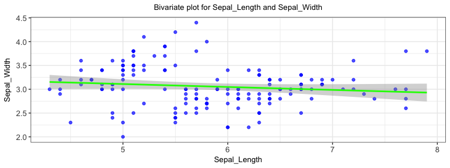

```r
opWithoutFilter %>>% getOutputById(1)
```

We then perform filtering on one of the variables in Spark, before visualizing in R

```r
pipelineObj %>>% filterData_spark(condition = "Species == 'setosa'") %>>%
  rBivarPlots(select_var_name_1 = "Sepal_Length", select_var_name_2 =  "Sepal_Width",
                     priColor = "blue", secColor = "green", outAsIn = T, storeOutput = T) -> singleFilterPipeline
singleFilterPipeline %>>% visualizePipeline
```

```
## INFO [2018-12-15 13:54:41] ||  Pipeline Prep. STARTED  ||
## INFO [2018-12-15 13:54:42] ||  Pipeline Prep. COMPLETE. Time taken : 0.00972414016723633 seconds||
```

[interactive chart not shown]

```r
singleFilterPipeline %>>% generateOutput -> opWithFilter
```

```
## INFO [2018-12-15 13:54:42] ||  Engine Assessment for pipeline STARTED  ||
## INFO [2018-12-15 13:54:42] ||  Engine Assessment COMPLETE. Time taken : 0.0193469524383545 seconds||
## INFO [2018-12-15 13:54:42] ||  Pipeline Prep. STARTED  ||
## INFO [2018-12-15 13:54:42] ||  Pipeline Prep. COMPLETE. Time taken : 0.00920200347900391 seconds||
## INFO [2018-12-15 13:54:42] ||  Pipeline Execution STARTED  ||
## INFO [2018-12-15 13:54:42] ||  Executing Batch Number : 1/2 containing functions 'filterData_spark' ||
## INFO [2018-12-15 13:54:42] ||  Function ID '1' named 'filterData_spark' STARTED on the 'spark' engine ||
## INFO [2018-12-15 13:54:46] ||  Type conversion from R dataframe to Spark DataFrame took 4.67936992645264 seconds  ||
## INFO [2018-12-15 13:54:47] ||  Function ID '1' named 'filterData_spark' COMPLETED. Time taken : 4.80434393882751 seconds  ||
## INFO [2018-12-15 13:54:47] ||  Batch Number 1/2 COMPLETE. Time taken : 4.81292796134949 seconds  ||
## INFO [2018-12-15 13:54:47] ||  Executing Batch Number : 2/2 containing functions 'rBivarPlots' ||
## INFO [2018-12-15 13:54:47] ||  Cleared intermediate outputs which are not required  ||
## INFO [2018-12-15 13:54:47] ||  Function ID '2' named 'rBivarPlots' STARTED on the 'r' engine ||
## INFO [2018-12-15 13:54:48] ||  Type conversion from Spark DataFrame to R dataframe took 1.42104315757751 seconds  ||
## INFO [2018-12-15 13:54:48] ||  Function ID '2' named 'rBivarPlots' COMPLETED. Time taken : 1.43864488601685 seconds  ||
## INFO [2018-12-15 13:54:48] ||  Batch Number 2/2 COMPLETE. Time taken : 1.4505980014801 seconds  ||
## INFO [2018-12-15 13:54:48] ||  Performing final garbage cleaning and collection of outputs  ||
## INFO [2018-12-15 13:54:48] ||  Pipeline Execution COMPLETE. Time taken : 6.28176784515381 seconds||
```

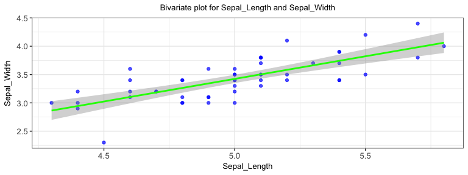

```r
opWithFilter %>>% getOutputById(2)
```

Finally, we show a case, where sequential filtering steps are performed in Spark, before visualizing in R, and running a decision tree model in Python.

```r
pipelineObj %>>% filterData_spark(condition = "Species == 'setosa' or Species == 'virginica'") %>>%
  filterData_spark(condition = "Petal_Length > 3.7", outAsIn = T) %>>%
  rBivarPlots(select_var_name_1 = "Sepal_Length", select_var_name_2 =  "Sepal_Width",
                     priColor = "blue", secColor = "green", outAsIn = T, storeOutput = T) %>>%
  getFeaturesForPyClassification(dataset = ~f2, featureNames = c("Sepal_Length",
                                                                 "Sepal_Width",
                                                                 "Petal_Length")) %>>%
          getTargetForPyClassification(dataset = ~f2, targetVarName = "Species", positiveClass = "setosa") %>>%
          decisionTreeTrainAndTest_py(data = ~f4, target = ~f5, newData = ~f4, storeOutput = T) -> twoFilterPipeline

twoFilterPipeline %>>% visualizePipeline
```

```
## INFO [2018-12-15 13:54:48] ||  Pipeline Prep. STARTED  ||
## INFO [2018-12-15 13:54:48] ||  Pipeline Prep. COMPLETE. Time taken : 0.0122089385986328 seconds||
```

[interactive chart not shown]

```r
twoFilterPipeline %>>% generateOutput -> opWith2Filters
```

```
## INFO [2018-12-15 13:54:48] ||  Engine Assessment for pipeline STARTED  ||
## INFO [2018-12-15 13:54:49] ||  Engine Assessment COMPLETE. Time taken : 0.0259740352630615 seconds||
## INFO [2018-12-15 13:54:49] ||  Pipeline Prep. STARTED  ||
## INFO [2018-12-15 13:54:49] ||  Pipeline Prep. COMPLETE. Time taken : 0.011646032333374 seconds||
## INFO [2018-12-15 13:54:49] ||  Pipeline Execution STARTED  ||
## INFO [2018-12-15 13:54:49] ||  Executing Batch Number : 1/4 containing functions 'filterData_spark' ||
## INFO [2018-12-15 13:54:49] ||  Function ID '1' named 'filterData_spark' STARTED on the 'spark' engine ||
## INFO [2018-12-15 13:54:49] ||  Type conversion from R dataframe to Spark DataFrame took 0.0806021690368652 seconds  ||
## INFO [2018-12-15 13:54:49] ||  Function ID '1' named 'filterData_spark' COMPLETED. Time taken : 0.108362913131714 seconds  ||
## INFO [2018-12-15 13:54:49] ||  Batch Number 1/4 COMPLETE. Time taken : 0.116430997848511 seconds  ||
## INFO [2018-12-15 13:54:49] ||  Executing Batch Number : 2/4 containing functions 'filterData_spark' ||
## INFO [2018-12-15 13:54:49] ||  Cleared intermediate outputs which are not required  ||
## INFO [2018-12-15 13:54:49] ||  Function ID '2' named 'filterData_spark' STARTED on the 'spark' engine ||
## INFO [2018-12-15 13:54:49] ||  Function ID '2' named 'filterData_spark' COMPLETED. Time taken : 0.0340428352355957 seconds  ||
## INFO [2018-12-15 13:54:49] ||  Batch Number 2/4 COMPLETE. Time taken : 0.0534820556640625 seconds  ||
## INFO [2018-12-15 13:54:49] ||  Executing Batch Number : 3/4 containing functions 'rBivarPlots, getFeaturesForPyClassification, getTargetForPyClassification' ||
## INFO [2018-12-15 13:54:49] ||  Cleared intermediate outputs which are not required  ||
## INFO [2018-12-15 13:54:49] ||  Function ID '3' named 'rBivarPlots' STARTED on the 'r' engine ||
## INFO [2018-12-15 13:54:49] ||  Type conversion from Spark DataFrame to R dataframe took 0.202119112014771 seconds  ||
## INFO [2018-12-15 13:54:49] ||  Function ID '3' named 'rBivarPlots' COMPLETED. Time taken : 0.217000007629395 seconds  ||
## INFO [2018-12-15 13:54:49] ||  Function ID '4' named 'getFeaturesForPyClassification' STARTED on the 'r' engine ||
## INFO [2018-12-15 13:54:49] ||  Type conversion from Spark DataFrame to R dataframe took 0.156191110610962 seconds  ||
## INFO [2018-12-15 13:54:49] ||  Function ID '4' named 'getFeaturesForPyClassification' COMPLETED. Time taken : 0.166799068450928 seconds  ||
## INFO [2018-12-15 13:54:49] ||  Function ID '5' named 'getTargetForPyClassification' STARTED on the 'r' engine ||
## INFO [2018-12-15 13:54:49] ||  Type conversion from Spark DataFrame to R dataframe took 0.127884864807129 seconds  ||
## INFO [2018-12-15 13:54:49] ||  Function ID '5' named 'getTargetForPyClassification' COMPLETED. Time taken : 0.13968300819397 seconds  ||
## INFO [2018-12-15 13:54:49] ||  Batch Number 3/4 COMPLETE. Time taken : 0.542998075485229 seconds  ||
## INFO [2018-12-15 13:54:49] ||  Executing Batch Number : 4/4 containing functions 'decisionTreeTrainAndTest_py' ||
## INFO [2018-12-15 13:54:49] ||  Cleared intermediate outputs which are not required  ||
## INFO [2018-12-15 13:54:49] ||  Function ID '6' named 'decisionTreeTrainAndTest_py' STARTED on the 'python' engine ||
## INFO [2018-12-15 13:54:49] ||  Type conversion from Pandas DataFrame to R dataframe took 0.00796794891357422 seconds  ||
## INFO [2018-12-15 13:54:49] ||  Function ID '6' named 'decisionTreeTrainAndTest_py' COMPLETED. Time taken : 0.0187051296234131 seconds  ||
## INFO [2018-12-15 13:54:49] ||  Batch Number 4/4 COMPLETE. Time taken : 0.0305378437042236 seconds  ||
## INFO [2018-12-15 13:54:49] ||  Performing final garbage cleaning and collection of outputs  ||
## INFO [2018-12-15 13:54:49] ||  Pipeline Execution COMPLETE. Time taken : 0.767184019088745 seconds||
```

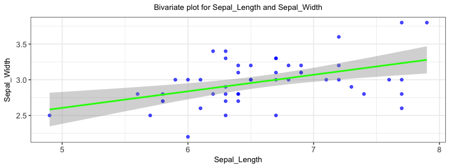

```r
opWith2Filters %>>% getOutputById(3)
```

```r
opWith2Filters %>>% getOutputById(6)
```

```
##  [1] "0" "0" "0" "0" "0" "0" "0" "0" "0" "0" "0" "0" "0" "0" "0" "0" "0"
## [18] "0" "0" "0" "0" "0" "0" "0" "0" "0" "0" "0" "0" "0" "0" "0" "0" "0"
## [35] "0" "0" "0" "0" "0" "0" "0" "0" "0" "0" "0" "0" "0" "0" "0" "0"
```

# Supplementary Note

The *analysisPipelines* package internally uses the *SparkR* package to interface with *Spark*. *SparkR* masks many typical data manipulation and processing functions from *base* as well as packages like *dplyr*. Therefore, ensure you use function scoping when calling a function.